# Land Cover in British Columbia

Google Earth Engine + R: ESA WorldCover vs AAFC Annual Crop Inventory

Isaac Qi

2026-02-04

```r
library(stargazer)
library(tidyverse)
library(sf)
library(terra)
library(scales)
library(knitr)
library(kableExtra)
library(raster)
library(here)
library(rnaturalearth) # for global spatial boundaries
library(bcmaps) # for BC spatial data (including boundaries)
```

## Project Overview

This report documents a district-level land cover analysis for British Columbia (BC), Canada using Google Earth Engine (GEE) and R.

- **GEE Script for ESA WorldCover TIF Export**: https://code.earthengine.google.com/c29eb93def8659d73f21f29ebed2f218
- **GEE Script for WorldCover CSV**: https://code.earthengine.google.com/e0f8b48a461e35e48f6111160ffa54c5
- **GEE Script for AAFC TIF Export**: https://code.earthengine.google.com/32ca340f18401b328d8b09f988995c67
- **GEE Script for AAFC CSV**: https://code.earthengine.google.com/5ac4dc0b5d565ab1b9acbad94d66bf01

## Question 1 — ESA WorldCover (2021)

### 1a) Data Product Description

European Space Agency WorldCover 10 m v200 is a global land-cover map with global spatial extent and a temporal extent of 2021. Its spatial resolution is 10 m, and it is an annual snapshot for the reference year 2021, meaning that its temporal resolution is annual (Van De Kerchove et al., 2022; Zanaga et al., 2021).

It was generated using a combination of Sentinel-1 synthetic aperture radar (SAR) data and Sentinel-2 multispectral optical imagery. Sentinel-1 data were acquired in Interferometric Wide (IW) mode, with an approximate spatial resolution of 5 × 20m and a temporal resolution of 12-days per satellite (NASA Earthdata, n.d.). Sentinel-2 imagery contributes data at 10m and 20m spatial resolutions, depending on the spectral band. It has a temporal resolution of ~5–6 days when both Sentinel-2 satellites are considered. These inputs were harmonized and processed to produce a global land-cover classification at 10 m spatial resolution (Van De Kerchove et al., 2022).

The overall accuracy of the ESA WorldCover product was validated by Wageningen University for statistical accuracy and IIASA for spatial accuracy, where it reached an overall accuracy of 76.7% (Tsendbazar et al., 2022). The table below includes a break down of overall accuracy per continent.

```r
worldcover_accuracy <- tibble::tribble(
  ~Region, ~`Overall accuracy`,
  "Global", "76.7 ± 0.5",
  "Africa", "76.5 ± 1.3",
  "Europe", "77.9 ± 1.0",
  "Eurasia", "72.5 ± 1.3",
  "Asia", "82.1 ± 1.0",
  "Oceania and Australia", "72.5 ± 1.3",
  "North America", "74.6 ± 1.2",
  "South America", "77.9 ± 1.1"
)

stargazer_table_html(
  worldcover_accuracy,
  title = "Overall Accuracy for the WorldCover 2021 v200 Data Product"
)
```

**Overall Accuracy for the WorldCover 2021 v200 Data Product**

| Region | Overall accuracy |
| --- | --- |
| Global | 76.7 ± 0.5 |
| Africa | 76.5 ± 1.3 |
| Europe | 77.9 ± 1.0 |
| Eurasia | 72.5 ± 1.3 |
| Asia | 82.1 ± 1.0 |
| Oceania and Australia | 72.5 ± 1.3 |
| North America | 74.6 ± 1.2 |
| South America | 77.9 ± 1.1 |

### 1b) Land Cover Categories

The ESA WorldCover product includes the following 11 classes (Van De Kerchove et al., 2022):

```r
product_classes <- tribble(
  ~`Map Code`, ~`Land Cover Class`,
  10, "Tree cover",
  20, "Shrubland",
  30, "Grassland",
  40, "Cropland",
  50, "Built-up",
  60, "Bare / sparse vegetation",
  70, "Snow and ice",
  80, "Permanent water bodies",
  90, "Herbaceous wetland",
  95, "Mangroves",
  100, "Moss and lichen"
)

stargazer_table_html(
  product_classes,
  title = "ESA WorldCover Land Cover Classes"
)
```

**ESA WorldCover Land Cover Classes**

| Map Code | Land Cover Class |
| --- | --- |
| 10 | Tree cover |
| 20 | Shrubland |
| 30 | Grassland |
| 40 | Cropland |
| 50 | Built-up |
| 60 | Bare / sparse vegetation |
| 70 | Snow and ice |
| 80 | Permanent water bodies |
| 90 | Herbaceous wetland |
| 95 | Mangroves |
| 100 | Moss and lichen |

### 1c) Fraser Valley Visualization

#### (i) Map Visualization with Legend

The land cover image for Fraser Valley District was exported from Google Earth Engine and visualized below with a custom legend showing the 11 ESA WorldCover classes.

```r
# load the Fraser Valley visualized image
fv_rast <- rast("data/FV_transparent.tif")

# ESA WorldCover color scheme and labels for the legend
landcover_classes <- tribble(
  ~Value, ~Color, ~Description,
  10, "#006400", "Tree cover",
  20, "#ffbb22", "Shrubland",
  30, "#ffff4c", "Grassland",
  40, "#f096ff", "Cropland",
  50, "#fa0000", "Built-up",
  60, "#b4b4b4", "Bare / sparse vegetation",
  70, "#f0f0f0", "Snow and ice",
  80, "#0064c8", "Permanent water bodies",
  90, "#0096a0", "Herbaceous wetland",
  95, "#00cf75", "Mangroves",
  100, "#fae6a0", "Moss and lichen"
)

# drop black pixels
fv_rast[fv_rast == 0] <- NA
```

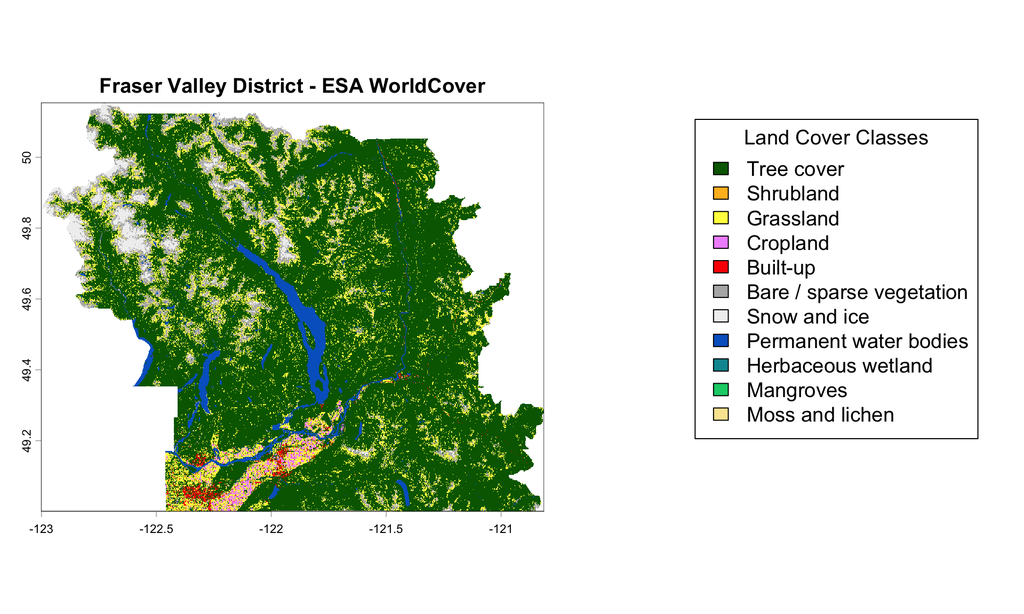

```r
# create two-panel layout: map on left, legend on right
layout(matrix(c(1, 2), nrow = 1), widths = c(2, 1.5))

# plot the map
# par(mar = c(1, 1, 3, 1))
plot(fv_rast,
     col = landcover_classes$Color,
     main = "Fraser Valley District - ESA WorldCover")

# create legend panel
# par(mar = c(1, 0, 3, 1))
plot.new()
legend(x = 0.05, y = 0.95,
       legend = landcover_classes$Description,
       fill = landcover_classes$Color,
       border = "black",
       title = "Land Cover Classes",
       cex = 1.2,
       bty = "o")
```

#### (ii) Area Calculation by Land Cover Type in the Fraser Valley

```r
# load worldcover CSV data
worldcover_data <- read_csv((here("data", "worldcover.csv")), show_col_types = FALSE) %>%
  rename(District = district) %>%
  dplyr::select(District, everything())

worldcover_data[is.na(worldcover_data)] <- 0

# extract Fraser Valley data
fraser_valley <- worldcover_data %>%
  filter(District == "Fraser Valley")

# Display Fraser Valley data with scrollable table
fraser_valley %>%
  kable(format = "html",
        caption = "Land Cover Area (km²) by Type in the Fraser Valley",
        digits = 1) %>%
  kable_styling(bootstrap_options = c("striped", "hover", "condensed", "responsive"),
                full_width = TRUE,
                position = "center",
                font_size = 11) %>%
  column_spec(1, bold = TRUE, width = "2.5cm") %>%
  scroll_box(width = "100%", height = "300px")
```

Land Cover Area (km²) by Type in the Fraser Valley

| District | Tree cover | Moss and lichen | Shrubland | Grassland | Cropland | Built-up | Bare / sparse vegetation | Snow and ice | Permanent water bodies | Herbaceous wetland | Mangroves |
| --- | --- | --- | --- | --- | --- | --- | --- | --- | --- | --- | --- |
| Fraser Valley | 10165 | 338 | 2 | 1557 | 123 | 91 | 746 | 328 | 549 | 0 | 0 |

The numbers obtained through GEE’s export makes sense when compared with the visualization. Tree cover dominates other land cover types at 10,165 km$^2$, which is evident by the large dark green area in the visualization. This also makes sense realistically given that the Fraser Valley is largely forested. Permanent water bodies, cropland, and built-up is also consistent with the visualization as well as the values extracted; we see that water covers 549 km$^2$ of land cover in the Fraser Valley, consistent with BC’s overall abundance in hydro resources. We can visually see the distribution of cropland and built-up along the lower lip of the Fraser Valley, consistent with the urban centers and agricultural areas in the district.

### 1d) British Columbia - Cover Type Distribution

The CSV file for BC’s land cover data was exported from Google Earth Engine; link to the code is included in the beginning of the report.

```r
# display data
display_data <- worldcover_data %>%
  head() # only first few rows

# customization for html output
out <- capture.output(stargazer(
  display_data,
  type = "html",
  summary = FALSE,
  rownames = FALSE,
  title = "Land Cover Area (km<sup>2</sup>) by District in British Columbia"
))
html <- paste(out, collapse = "\n")
html <- sub(
  "<table",
  "<table class='bc-equal-cols' style='margin-left:auto;margin-right:auto;'",
  html
)
knitr::asis_output(paste0(
  "<style>
    /* local: force equal column widths for this one table */
    table.bc-equal-cols { table-layout: fixed; width: 100%; font-size: 0.8em; }
    table.bc-equal-cols th, table.bc-equal-cols td {
      width: 1%;
      /* wrap between words, not within a word */
      white-space: normal;
      word-break: keep-all;
      overflow-wrap: normal;
    }
  </style>",
  "<div style='text-align:center;'>",
  html,
  "</div><br>"
))
```

**Land Cover Area (km<sup>2</sup>) by District in British Columbia**

| District | Tree cover | Moss and lichen | Shrubland | Grassland | Cropland | Built-up | Bare / sparse vegetation | Snow and ice | Permanent water bodies | Herbaceous wetland | Mangroves |
| --- | --- | --- | --- | --- | --- | --- | --- | --- | --- | --- | --- |
| Comox Valley | 1356 | 13 | 0 | 295 | 5 | 16 | 11 | 1 | 41 | 0 | 0 |
| Strathcona | 13315 | 441 | 1 | 1363 | 1 | 12 | 1155 | 1918 | 444 | 0 | 0 |
| Alberni-Clayoquot | 6043 | 45 | 0 | 389 | 1 | 11 | 60 | 12 | 330 | 0 | 0 |
| Bulkley-Nechako | 60987 | 2126 | 6 | 8054 | 129 | 38 | 1528 | 526 | 4806 | 4 | 0 |
| Capital | 2085 | 0 | 0 | 170 | 3 | 56 | 4 | 0 | 52 | 0 | 0 |
| Cariboo | 60946 | 2317 | 13 | 12549 | 86 | 47 | 3250 | 1355 | 2376 | 11 | 0 |

## Question 2 — Canada AAFC Annual Crop Inventory

### 2a) Data Product Description

The Canada AAFC Annual Crop Inventory is produced by Agriculture and Agri-Food Canada (AAFC)’s Earth Observation Team. The spatial extent covers most of Canada, focusing on agricultural regions. The temporal extent spans from 2009 to the present, with annual updates making the temporal resolution annual. The spatial resolution is 30m, derived from optical and radar based satellite imagery including Landsat-5, AWiFS, DMC, and RADARSAT-2 based data (Agriculture and Agri-Food Canada, 2023).

The underlying satellite data sources include: - **Landsat-5**: 30m spatial resolution, 16-day temporal resolution (NASA, n.d.)

- **AWiFS (Advanced Wide Field Sensor)**: 56m spatial resolution, 5-day revisit period (United States Geological Survey, n.d.)
- **DMC (Disaster Monitoring Constellation)**: 4m spatial resolution, daily revisit time (eoPortal, n.d.a)
- **RADARSAT-2**: 3-100m spatial resolution, 4-day temporal resolution (eoPortal, n.d.b; Huntley et al., 2021)

The overall accuracy of this data product is at minimum 85% at the final spatial resolution of 30m (Agriculture and Agri-Food Canada, 2023).

### 2b) Land Cover Categories

The AAFC Annual Crop Inventory includes detailed agricultural classifications plus broader land cover classes. Land Cover categories include:

```r
aafc_data <- read_csv(here("data", "aafc.csv"), show_col_types = FALSE) %>%
  rename(District = district) %>%
  dplyr::select(District, everything())

aafc_data[is.na(aafc_data)] <- 0

aafc_columns <- names(aafc_data)[names(aafc_data) != "District"]

aafc_categories <- tibble(
  `Land Cover Class` = aafc_columns
)

stargazer_table_html(
  aafc_categories,
  title = "AAFC Annual Crop Inventory Land Cover Classes"
)
```

**AAFC Annual Crop Inventory Land Cover Classes**

| Land Cover Class |
| --- |
| Cloud |
| Grassland |
| Agriculture (undifferentiated) |
| Pasture and Forages |
| Too Wet to be Seeded |
| Fallow |
| Cereals |
| Barley |
| Other Grains |
| Millet |
| Oats |
| Rye |
| Spelt |
| Triticale |
| Wheat |
| Switchgrass |
| Sorghum |
| Quinoa |
| Winter Wheat |
| Spring Wheat |
| Corn |
| Tobacco |
| Ginseng |
| Oilseeds |
| Borage |
| Camelina |
| Canola and Rapeseed |
| Flaxseed |
| Mustard |
| Safflower |
| Sunflower |
| Soybeans |
| Pulses |
| Other Pulses |
| Peas |
| Chickpeas |
| Beans |
| Fababeans |
| Lentils |
| Vegetables |
| Tomatoes |
| Potatoes |
| Sugarbeets |
| Other Vegetables |
| Fruits |
| Berries |
| Blueberry |
| Cranberry |
| Other Berry |
| Orchards |
| Other Fruits |
| Vineyards |
| Hops |
| Sod |
| Herbs |
| Nursery |
| Buckwheat |
| Canaryseed |
| Hemp |
| Vetch |
| Other Crops |
| Water |
| Forest (undifferentiated) |
| Coniferous |
| Broadleaf |
| Mixedwood |
| Exposed Land and Barren |
| Urban and Developed |
| Greenhouses |
| Shrubland |
| Wetland |
| Peatland |

### 2c) Fraser Valley Visualization

#### (i) Map Visualization with Legend

The land cover image for Fraser Valley District was exported from Google Earth Engine using the AAFC Annual Crop Inventory dataset.

```r
# Load the Fraser Valley AAFC visualized image
fv_aafc_rast <- rast("data/FV_unVisualized_AAFC.tif")

# AAFC color scheme - all land cover types present in BC with official colors, ordered by importance
aafc_classes <- tribble(
  ~Code, ~Color, ~Description,
  210, "#006600", "Coniferous",
  30, "#996666", "Exposed Land and Barren",
  50, "#ffff00", "Shrubland",
  220, "#00cc00", "Broadleaf",
  80, "#993399", "Wetland",
  230, "#cc9900", "Mixedwood",
  110, "#cccc00", "Grassland",
  20, "#3333ff", "Water",
  34, "#cc6699", "Urban and Developed",
  122, "#ffcc33", "Pasture and Forages",
  120, "#cc6600", "Agriculture (undifferentiated)",
  153, "#d6ff70", "Canola and Rapeseed",
  133, "#dae31d", "Barley",
  146, "#92a55b", "Spring Wheat",
  162, "#8f6c3d", "Peas",
  147, "#ffff99", "Corn",
  188, "#ff6666", "Orchards",
  182, "#d20000", "Blueberry",
  131, "#ff9900", "Fallow",
  136, "#d1d52b", "Oats",
  190, "#7442bd", "Vineyards",
  183, "#cc0000", "Cranberry",
  167, "#82654a", "Beans",
  185, "#dc3200", "Other Berry",
  137, "#cacd32", "Rye",
  35, "#e1e1e1", "Greenhouses",
  145, "#809769", "Winter Wheat",
  177, "#ffcccc", "Potatoes",
  179, "#ffccff", "Other Vegetables",
  192, "#b5fb05", "Sod",
  194, "#07f98c", "Nursery",
  175, "#b74b15", "Vegetables",
  139, "#b9bc44", "Triticale",
  130, "#7899f6", "Too Wet to be Seeded",
  199, "#749a66", "Other Crops",
  189, "#c5453b", "Other Fruits",
  168, "#a39069", "Fababeans",
  197, "#8e7672", "Hemp",
  191, "#ffcc99", "Hops",
  174, "#b85900", "Lentils",
  160, "#896e43", "Pulses",
  155, "#d6cc00", "Mustard",
  154, "#8c8cff", "Flaxseed"
)

# Handle no-data values
fv_aafc_rast[fv_aafc_rast == 0] <- NA
```

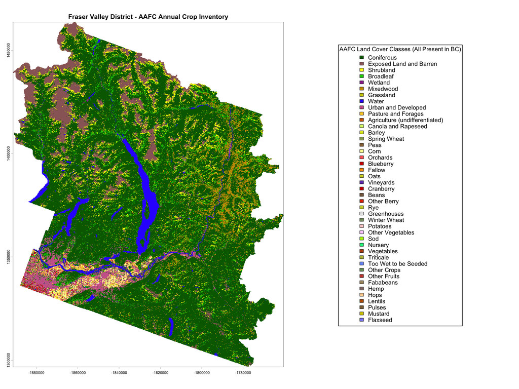

```r
# create two-panel layout: map on left, legend on right
layout(matrix(c(1, 2), nrow = 1), widths = c(2, 1.5))

plot(fv_aafc_rast,
     main = "Fraser Valley District - AAFC Annual Crop Inventory",
     col = aafc_classes$Color,
     legend = FALSE)

plot.new()
par(mar = c(1, 1, 1, 1))

legend(x = 0.05, y = 0.98,
       legend = aafc_classes$Description,
       fill = aafc_classes$Color,
       border = "black",
       title = "AAFC Land Cover Classes (All Present in BC)",
       cex = 1.1,
       bty = "o",
       xjust = 0,
       yjust = 1,
       box.lwd = 1.5,
       box.col = "black")
```

#### (ii) Area Calculation by Land Cover Type in the Fraser Valley

```r
fraser_valley_aafc <- aafc_data %>%
  filter(District == "Fraser Valley") %>%
  dplyr::select(where(~ !all(. == 0))) %>%
  mutate(across(-District, ~ round(. / 1000000, 2)))

# Display Fraser Valley AAFC data with scrollable table
fraser_valley_aafc %>%
  kable(format = "html",
        caption = "Land Cover Area (km²) by Type in the Fraser Valley - AAFC Data",
        digits = 2) %>%
  kable_styling(bootstrap_options = c("striped", "hover", "condensed", "responsive"),
                full_width = TRUE,
                position = "center",
                font_size = 11) %>%
  column_spec(1, bold = TRUE, width = "2.5cm") %>%
  scroll_box(width = "100%", height = "300px")
```

Land Cover Area (km²) by Type in the Fraser Valley - AAFC Data

| District | Grassland | Agriculture (undifferentiated) | Pasture and Forages | Fallow | Barley | Corn | Beans | Potatoes | Other Vegetables | Blueberry | Cranberry | Other Berry | Orchards | Other Fruits | Vineyards | Hops | Sod | Nursery | Other Crops | Water | Coniferous | Broadleaf | Mixedwood | Exposed Land and Barren | Urban and Developed | Greenhouses | Shrubland | Wetland |
| --- | --- | --- | --- | --- | --- | --- | --- | --- | --- | --- | --- | --- | --- | --- | --- | --- | --- | --- | --- | --- | --- | --- | --- | --- | --- | --- | --- | --- |
| Fraser Valley | 43.9 | 0.07 | 94.59 | 0.34 | 0.03 | 108.78 | 0.08 | 1.79 | 2.76 | 28.24 | 1.02 | 5.9 | 0.47 | 0.02 | 0.66 | 0.06 | 2.44 | 1.15 | 0.62 | 512 | 9343.79 | 787.1 | 619.12 | 1136.48 | 462.45 | 2.4 | 703.65 | 39.11 |

The AAFC data shows a different perspective on Fraser Valley land cover compared to ESA WorldCover. Rather than looking at land cover type, it is now separated into agricultural commodities. The data corroborates the visualization, though specifics are hard to pick out visually due to the level of detail provided by the AAFC dataset. We can see that there is much diversity in the bottom left border of the Fraser Valley.

### 2d) British Columbia - AAFC Cover Type Distribution

#### (i) Missing Data

Based on visual inspection of the data as well as through GEE’s inspector UI, several districts in British Columbia have incomplete information due to the product’s focus on agricultural areas. These include:

- **Central Coast** - Minimal agricultural coverage
- **Mount Waddington** - Limited to small agricultural pockets
- **Northern Rockies** - Limited agricultural development
- **Skeena-Queen Charlotte** - Very limited agricultural areas
- **Stikine** - Minimal agricultural areas

Through GEE’s inspector UI, I also identified **Kitimat-Stikine** to have sparse agricultural coverage.

```r
missing_aafc <- aafc_data %>%
  filter(`Agriculture (undifferentiated)` == 0) %>%
  filter(Potatoes == 0) %>%
  filter(`Pasture and Forages` == 0)

print(missing_aafc$District)
```

```
[1] "Central Coast"          "Mount Waddington"       "Northern Rockies"
[4] "Skeena-Queen Charlotte" "Stikine"
```

#### (ii) Total Land Cover Area

The CSV file for BC’s AAFC land cover data was exported from Google Earth Engine; link to the code is included at the beginning of the report. Note that given the amount of categories available, I’ve filtered out any columns that are completely 0, as in not produced in BC as a whole.

```r
# display data
aafc_nozero_data <- aafc_data %>%
  dplyr::select(where(~ any(. != 0))) %>%
  mutate(across(-District, ~ round(. / 1000000, 2)))

aafc_display_data <- aafc_nozero_data %>%
  head()

# Display first few districts with scrollable table for better readability
aafc_display_data %>%
  kable(format = "html",
        caption = "Land Cover Area (km²) by District in British Columbia - AAFC Data (First 6 Districts)",
        digits = 2) %>%
  kable_styling(bootstrap_options = c("striped", "hover", "condensed", "responsive"),
                full_width = TRUE,
                position = "center",
                font_size = 11) %>%
  column_spec(1, bold = TRUE, width = "2.5cm") %>%
  scroll_box(width = "100%", height = "400px")
```

Land Cover Area (km²) by District in British Columbia - AAFC Data (First 6 Districts)

| District | Grassland | Agriculture (undifferentiated) | Pasture and Forages | Too Wet to be Seeded | Fallow | Barley | Oats | Rye | Triticale | Winter Wheat | Spring Wheat | Corn | Canola and Rapeseed | Flaxseed | Mustard | Pulses | Peas | Beans | Fababeans | Lentils | Vegetables | Potatoes | Other Vegetables | Blueberry | Cranberry | Other Berry | Orchards | Other Fruits | Vineyards | … |
| --- | --- | --- | --- | --- | --- | --- | --- | --- | --- | --- | --- | --- | --- | --- | --- | --- | --- | --- | --- | --- | --- | --- | --- | --- | --- | --- | --- | --- | --- | --- |
| Comox Valley | 1.12 | 36.56 | 0.00 | 0 | 0 | 0.00 | 0.00 | 0 | 0 | 0 | 0 | 0 | 0 | 0 | 0 | 0.00 | 0 | 0 | 0 | 0 | 0.00 | 0 | 0 | 0 | 0 | 0 | 0 | 0 | 0 | … |
| Strathcona | 275.56 | 1.69 | 0.00 | 0 | 0 | 0.00 | 0.00 | 0 | 0 | 0 | 0 | 0 | 0 | 0 | 0 | 0.00 | 0 | 0 | 0 | 0 | 0.00 | 0 | 0 | 0 | 0 | 0 | 0 | 0 | 0 | … |
| Alberni-Clayoquot | 2.42 | 6.87 | 0.00 | 0 | 0 | 0.00 | 0.00 | 0 | 0 | 0 | 0 | 0 | 0 | 0 | 0 | 0.00 | 0 | 0 | 0 | 0 | 0.00 | 0 | 0 | 0 | 0 | 0 | 0 | 0 | 0 | … |
| Bulkley-Nechako | 724.40 | 585.20 | 317.66 | 0 | 0 | 0.00 | 0.37 | 0 | 0 | 0 | 0 | 0 | 0 | 0 | 0 | 0.00 | 0 | 0 | 0 | 0 | 2.39 | 0 | 0 | 0 | 0 | 0 | 0 | 0 | 0 | … |
| Capital | 0.04 | 29.37 | 0.00 | 0 | 0 | 0.00 | 0.00 | 0 | 0 | 0 | 0 | 0 | 0 | 0 | 0 | 0.00 | 0 | 0 | 0 | 0 | 0.00 | 0 | 0 | 0 | 0 | 0 | 0 | 0 | 0 | … |
| Cariboo | 2988.32 | 72.22 | 387.22 | 0 | 0 | 0.72 | 0.00 | 0 | 0 | 0 | 0 | 0 | 0 | 0 | 0 | 0.04 | 0 | 0 | 0 | 0 | 0.12 | 0 | 0 | 0 | 0 | 0 | 0 | 0 | 0 | … |

### 2e) Cropland and Grassland Comparison

To compare cropland coverage between AAFC and WorldCover, I made the assumption that any land cover that produces crops, which includes greenhouses and nurseries - with this assumption, I hypothesize that it will lead to discrepancies with the WorldCover classification as they would likely fall under Built-up.

```r
fraser_aafc <- aafc_data %>%
  filter(District == "Fraser Valley") %>%
  dplyr::select(-Peatland, -Wetland, -Shrubland, -`Urban and Developed`, -`Exposed Land and Barren`, -`Mixedwood`, -`Broadleaf`, -`Coniferous`, -`Forest (undifferentiated)`, -Water, -Sod, -`Pasture and Forages`, -`Too Wet to be Seeded`)

fraser_valley_total_crop <- fraser_aafc %>%
  summarise(
    total_crop = sum(rowSums(
        dplyr::select(., where(is.numeric), -Grassland),
        na.rm = TRUE)))
```

**Comparison between WorldCover and AAFC:**

ESA WorldCover provides data at 10m resolution while AAFC data is at 30m resolution, however, GEE automatically converted using ee.Image.pixelArea() which outputs data in m$^2$ units. For my ESA data output, I’ve pre-rounded to km$^2$ using `var area = ee.Number(areaDict.get('sum')).divide(1e6).round();`, so to make the comparisons I will need to do the unit conversions for AAFC into $km^2$.

The ESA WorldCover data product showed that the district of Fraser Valley houses 123 km$^2$ of cropland and 1557 km$^2$ of grassland. Meanwhile, AAFC’s Annual Crop Inventory shows a sum of 154 km$^2$ of cropland and 44 km$^2$ of Grassland. I believe these differences are due to the following factors:

1. **Cropland** As hypothesized, AAFC’s cropland estimate should be larger than ESA WorldCover as I included nurseries and greenhouses as part of “cropland”’s definition, while WorldCover will likely classify them as buildings. Regardless, the estimates are quite similar, which brings confidence to the estimate.
2. **Grassland**: There is a very large difference between AAFC and ESA WorldCover’s estimate on grassland, where AAFC showed only 44 km$^2$ compared to ESA WorldCover’s 1557 km$^2$. As a sanity check, I added up the total area for both data products for the district of Fraser Valley.

```r
sanity_ESA <- fraser_valley %>%
  summarise(
    total_area = sum(rowSums(
        dplyr::select(., where(is.numeric)),
        na.rm = TRUE)))

sanity_aafc <- fraser_valley_aafc %>%
  summarise(
    total_area = sum(rowSums(
        dplyr::select(., where(is.numeric)),
        na.rm = TRUE)))

print(sanity_aafc$total_area)
```

```
[1] 13899.02
```

```r
print(sanity_ESA$total_area)
```

```
[1] 13899
```

The two data products returned near identical areas, which suggests there is no unit conversion / missing data issues.

It is possible that AAFC has more detailed classifications of natural terrain, such as wetland, peatland, Exposed Land and Barren, Sod etc; most importantly, AAFC’s Annual Crop Inventory has pasture and forages as its own category which is very likely to be classified as Grassland in the ESA WorldCover data. Overall, the granularity in AAFC’s data product likely led to this difference as ESA WorldCover included many of these types of terrain together.

## Question 3 — AAFC Land Cover Data Visualization

#### (i) Most Dominant Crop Type by District

In the AAFC data, there is a large category titled `Agriculture (undifferentiated)`. Since I’m interested in the specific crop type, I will filter out this category while acknowleding the limitations of my visualizations. I’ve also filtered out `Fallow`, which is land currently resting between seedings.

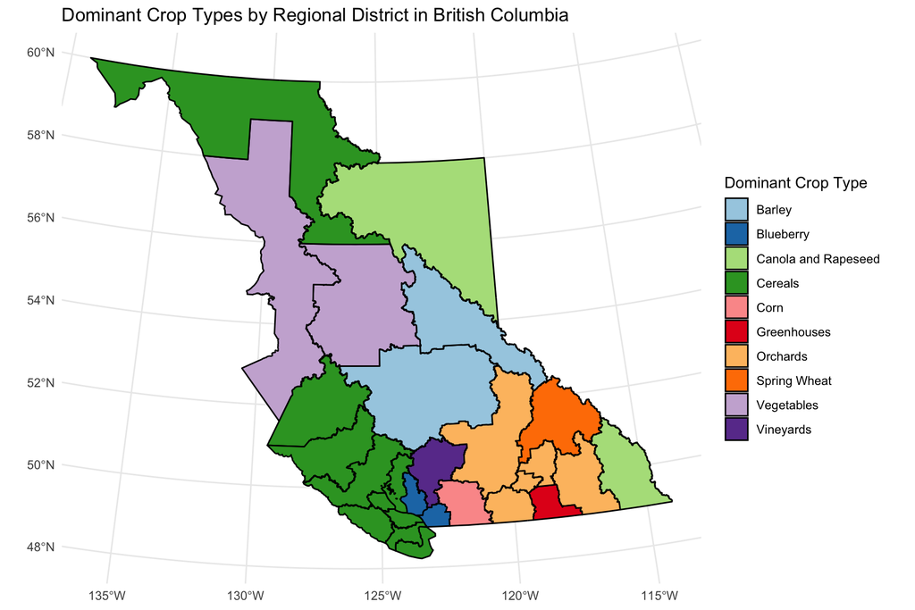

```r
dominant_crop <- aafc_data %>%
  dplyr::select(-Peatland, -Wetland, -Shrubland, -`Urban and Developed`, -`Exposed Land and Barren`, -`Mixedwood`, -`Broadleaf`, -`Coniferous`, -`Forest (undifferentiated)`, -Water, -Sod, -`Pasture and Forages`, -`Too Wet to be Seeded`, -Cloud, -Grassland, -`Agriculture (undifferentiated)`, -Fallow)

dominant_crop$max_column <- colnames(dominant_crop)[apply(dominant_crop, 1, which.max)]

dominant_crop <- dominant_crop %>%
  dplyr::select(District, max_column)

bc_admin2 <- regional_districts()

bc_admin2 <- bc_admin2 %>%
  mutate(District_clean = str_remove_all(ADMIN_AREA_NAME, "Regional District of |Regional District| Region \\(Unincorporated\\)"),
         District_clean = str_trim(District_clean),
         District_clean = case_when(
           District_clean == "Columbia Shuswap" ~ "Columbia-Shuswap",
           District_clean == "Metro Vancouver" ~ "Greater Vancouver",
           District_clean == "qathet" ~ "Powell River",
           TRUE ~ District_clean
         )) %>%
  dplyr::filter(ADMIN_AREA_NAME != "North Coast Regional District")

bc_crops <- bc_admin2 %>%
  left_join(dominant_crop, by = c("District_clean" = "District"))

ggplot() +
  geom_sf(data = bc_crops, aes(fill = max_column), color = "black", linewidth = 0.5) +
  scale_fill_brewer(palette = "Paired") +
  theme_minimal() +
  labs(fill = "Dominant Crop Type",
       title = "Dominant Crop Types by Regional District in British Columbia")
```

#### (ii) District Commodity Output

To better understand the scale of agricultural production across BC districts, I’ll visualize the total commodity output by district. This will show not just what is grown, but how much is produced in each area.

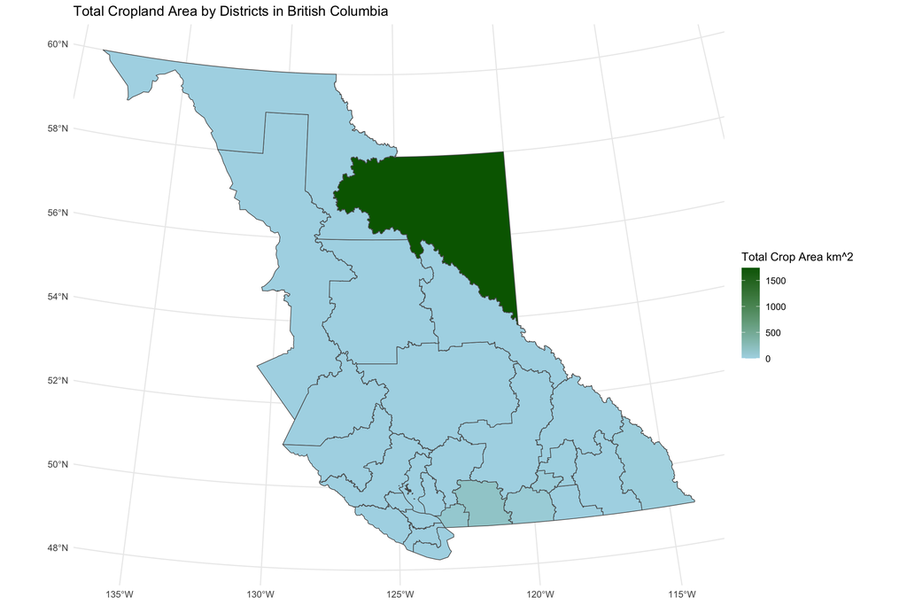

```r
# Calculate total crop production by district (excluding non-crop categories)
crop_totals <- aafc_data %>%
  dplyr::select(-Peatland, -Wetland, -Shrubland, -`Urban and Developed`,
                -`Exposed Land and Barren`, -`Mixedwood`, -`Broadleaf`,
                -`Coniferous`, -`Forest (undifferentiated)`, -Water, -Sod,
                -`Pasture and Forages`, -`Too Wet to be Seeded`, -Cloud,
                -Grassland, -`Agriculture (undifferentiated)`, -Fallow) %>%
  mutate(total_crop_area = rowSums(dplyr::select(., where(is.numeric)), na.rm = TRUE)) %>%
  dplyr::select(District, total_crop_area) %>%
  mutate(total_crop_area_km2 = total_crop_area / 1000000)

bc_crop_totals <- bc_admin2 %>%
  left_join(crop_totals, by = c("District_clean" = "District"))

ggplot() +
  geom_sf(data = bc_crop_totals, aes(fill = total_crop_area_km2), linewidth = 0.3) +
  scale_fill_gradient(low = "lightblue", high = "darkgreen", name = "Total Crop Area km^2") +
  theme_minimal() +
  labs(title = "Total Cropland Area by Districts in British Columbia")
```

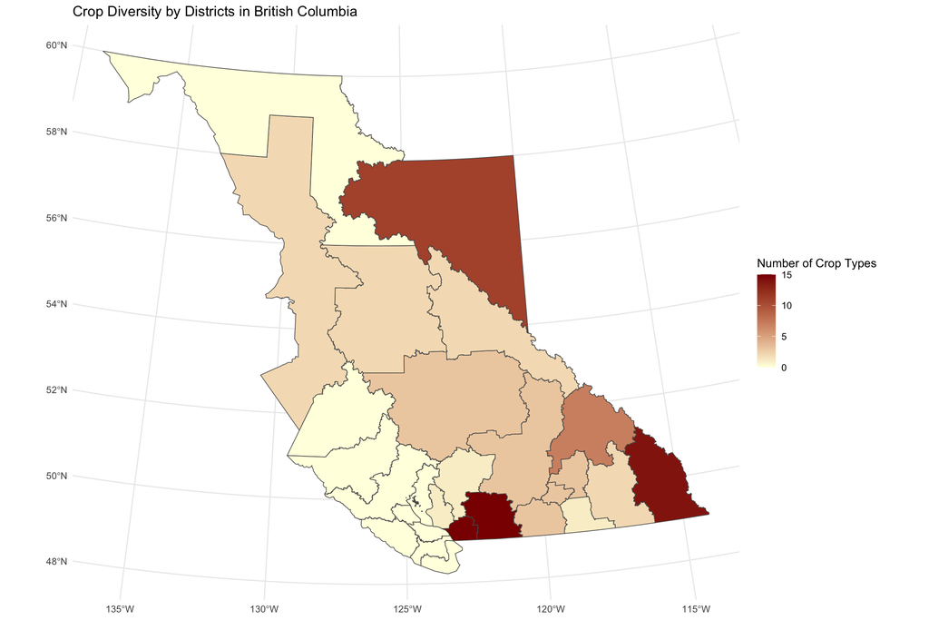

```r
# Analyze crop diversity by calculating number of different crops grown per district
crop_diversity <- aafc_data %>%
  dplyr::select(-Peatland, -Wetland, -Shrubland, -`Urban and Developed`,
                -`Exposed Land and Barren`, -`Mixedwood`, -`Broadleaf`,
                -`Coniferous`, -`Forest (undifferentiated)`, -Water, -Sod,
                -`Pasture and Forages`, -`Too Wet to be Seeded`, -Cloud,
                -Grassland, -`Agriculture (undifferentiated)`, -Fallow) %>%
  mutate(
    crop_diversity = rowSums(dplyr::select(., where(is.numeric)) > 0, na.rm = TRUE),
    total_crop_area = rowSums(dplyr::select(., where(is.numeric)), na.rm = TRUE)
  ) %>%
  dplyr::select(District, crop_diversity, total_crop_area) %>%
  mutate(total_crop_area_km2 = total_crop_area / 1000000)

# Join with spatial data
bc_crop_diversity <- bc_admin2 %>%
  left_join(crop_diversity, by = c("District_clean" = "District"))

# Create the diversity map
ggplot() +
  geom_sf(data = bc_crop_diversity, aes(fill = crop_diversity), linewidth = 0.3) +
  scale_fill_gradient(low = "lightyellow", high = "darkred",
                      name = "Number of Crop Types") +
  theme_minimal() +
  labs(title = "Crop Diversity by Districts in British Columbia")
```

## AI Use Disclaimer

AI was used in formatting the html styling and graphical coding. All code logic and interpretation are mine.

## References

Agriculture and Agri-Food Canada. (2023). *Annual crop inventory*. https://open.canada.ca/data/en/dataset/ba2645d5-4458-414d-b196-6303ac06c1c9.

eoPortal. (n.d.a). *DMC-3 (disaster monitoring constellation-3)*. https://www.eoportal.org/satellite-missions/dmc-3.

eoPortal. (n.d.b). *RADARSAT-2*. https://www.eoportal.org/satellite-missions/radarsat-2.

Huntley, D., Rotheram-Clarke, D., Pon, A., Tomaszewicz, A., Leighton, J., Cocking, R., & Joseph, J. (2021). Benchmarked RADARSAT-2, SENTINEL-1 and RADARSAT constellation mission change-detection monitoring at north slide, thompson river valley, british columbia: Ensuring a landslide-resilient national railway network. *Canadian Journal of Remote Sensing*, *47*(4), 635–656. https://doi.org/10.1080/07038992.2021.1937968

NASA. (n.d.). *Landsat 5*. https://science.nasa.gov/mission/landsat-5/.

NASA Earthdata. (n.d.). *Sentinel-1*. https://www.earthdata.nasa.gov/data/platforms/space-based-platforms/sentinel-1.

Tsendbazar, N., Xu, P., Herold, M., Lesiv, M., & Duerauer, M. (2022). *ESA WorldCover product validation report (v2.0)* (WorldCover_PVR_v2.0). ESA WorldCover Consortium (VITO/Wageningen University/IIASA). https://worldcover2021.esa.int/data/docs/WorldCover_PVR_V2.0.pdf

United States Geological Survey. (n.d.). *USGS EROS archive - ISRO resourcesat 1 and resourcesat 2 - AWiFS)*. https://www.usgs.gov/centers/eros/science/usgs-eros-archive-isro-resourcesat-1-and-resourcesat-2-awifs.

Van De Kerchove, R., Zanaga, D., Xu, P., Tsendbazar, N., & Lesiv, M. (2022). *ESA WorldCover product user manual (v2.0)* (WorldCover_PUM_v2.0). ESA WorldCover Consortium (VITO/Wageningen University/IIASA). https://worldcover2021.esa.int/data/docs/WorldCover_PUM_V2.0.pdf

Zanaga, D., Van De Kerchove, R., Daems, D., De Keersmaecker, W., Brockmann, C., Kirches, G., Wevers, J., Cartus, O., Santoro, M., Fritz, S., Lesiv, M., Herold, M., Tsendbazar, N. E., Xu, P., Ramoino, F., & Arino, O. (2021). *ESA WorldCover 10 m 2021 v200* [Dataset]. Zenodo. https://doi.org/10.5281/zenodo.7254221